# MLOps Monitoring Report, Pre-Production Defect Risk Scorer

Section 1

## Status & Retraining Decision

The retraining decision is led by directly-measured signals (model performance and defect-rate drift) because ground-truth outcomes for this shop land within the scoring period. Prediction and feature drift act as early proxies and diagnostic context, not primary triggers. The verdict below reflects the most recent period (Mar 2026); the sections that follow show the full trend.

✓ NO ACTION REQUIRED As of Mar 2026

Model Version v1 (Xgboost)

Trained December 15, 2025

Periods Monitored Jan 2026 to Mar 2026

Reference January 2023 to December 2024

High-Tier Precision 96.2%

Defect Rate Shift 5.1%

Features Drifted 1 / 17

Trigger Reasons

Retraining rules are evaluated every period. Primary rules measure harm directly; secondary rules are leading proxies that warrant investigation rather than immediate retraining.

|  | Tier | Rule | Status |
| --- | --- | --- | --- |
| ✓ | Primary | High-tier precision below 85% (measured performance) | OK |
| ✓ | Primary | Defect rate shifts more than 10% from training baseline | OK |
| ✓ | Secondary | Prediction (output) distribution drifts vs validation reference | OK |
| ✓ | Secondary | More than 3 input features drift vs training | OK |

The flag currently reads NO ACTION REQUIRED, meaning measured high-tier precision and defect-rate drift both stay within their retraining thresholds, so the model is behaving as expected in production. In practice, the current production model (v1) continues to score work orders unchanged, and monitoring repeats each period to catch any future drift before it reaches the floor.

Section 2

## MLOps Monitoring Summary

The layers below track the model every period. Measured performance and defect-rate (target) drift are the primary retraining triggers; prediction and feature drift are leading proxies; and data quality confirms the inputs feeding all of them are sound.

Section 2.1

## Performance

Precision and recall by risk tier against actual outcomes. These are the primary evidence for retraining decisions. Because labels arrive quickly here, measured performance is the strongest signal rather than a lagging one. **High-tier precision holds well above the 85% floor every period (89% to 97%), so the high-risk flags stay trustworthy and nothing in the performance layer calls for retraining.**

Precision & Recall by Tier, Jan 2026 to Mar 2026

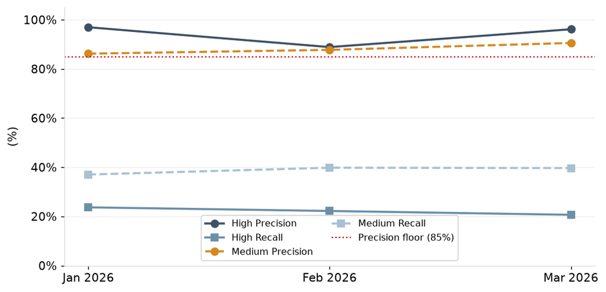

| Period | Scored | High Prec. | High Rec. | Med Prec. | Med Rec. |
| --- | --- | --- | --- | --- | --- |
| Jan 2026 | 270 | 97.0% | 23.7% | 86.2% | 37.0% |
| Feb 2026 | 206 | 88.9% | 22.2% | 87.8% | 39.8% |
| Mar 2026 | 219 | 96.2% | 20.7% | 90.6% | 39.7% |

Risk-tier mix shows the operational load each period places on the floor team, useful for calibrating review capacity against the High-risk count.

Risk-Tier Mix by Period

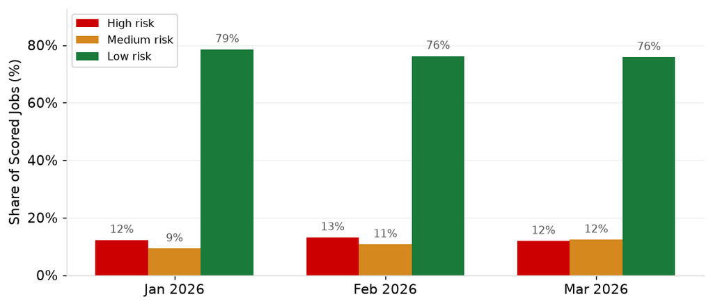

Section 2.2

## Target Drift

Actual defect rate per period versus the training baseline, as a rate comparison rather than a distribution distance, which is more interpretable for a binary outcome. A material shift signals the shop's underlying quality profile has changed, which can affect calibration even when inputs are stable. **The defect rate stays within about 5 points of the 50% baseline and never crosses the 10% trigger, so the underlying quality profile is stable and calibration is intact.**

Actual Defect Rate vs Training Baseline

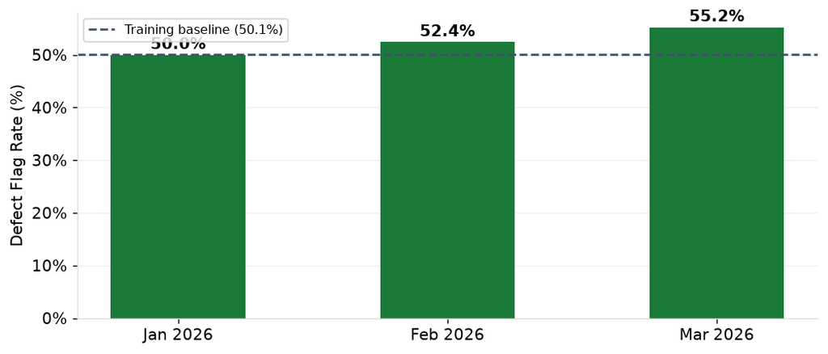

| Period | Actual Rate | Baseline | Δ | Status |
| --- | --- | --- | --- | --- |
| Jan 2026 | 50.0% | 50.1% | 0.1% | ✓ Stable |
| Feb 2026 | 52.4% | 50.1% | 2.3% | ✓ Stable |
| Mar 2026 | 55.2% | 50.1% | 5.1% | ✓ Stable |

Section 2.3

## Prediction Drift

Distribution of the model's predicted probabilities versus the validation-set reference, measured with the same distance method used for features. This is a label-free early indicator: it catches the model behaving differently regardless of which input moved. Here it corroborates the performance read rather than leading it. **Prediction-drift distance stays well below its threshold in every period, so the model's score distribution has not shifted, backing up the stable performance read.**

Prediction-Drift Distance by Period

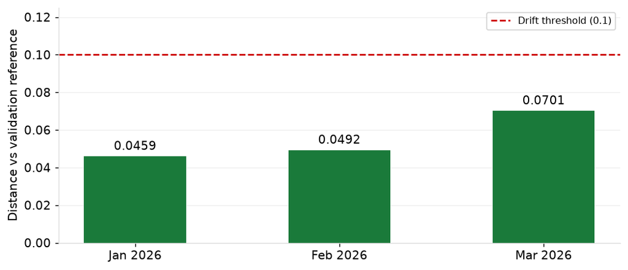

| Period | Distance | Threshold | Mean Score (ref→cur) | Status |
| --- | --- | --- | --- | --- |
| Jan 2026 | 0.0459 | 0.10 | 0.495 → 0.496 | ✓ Stable |
| Feb 2026 | 0.0492 | 0.10 | 0.495 → 0.500 | ✓ Stable |
| Mar 2026 | 0.0701 | 0.10 | 0.495 → 0.507 | ✓ Stable |

Score Distribution, Validation Reference vs Mar 2026

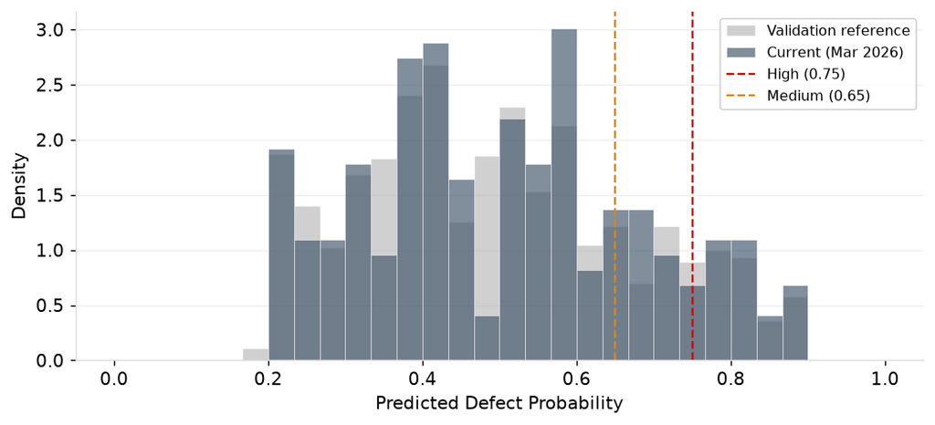

Section 2.4

## Feature Drift

Per-feature distance between each period's input distribution and the training reference (Jensen-Shannon for categoricals, normed Wasserstein for numericals). Values at or above 0.1 are flagged. Feature drift is diagnostic because it helps explain a performance change if one occurs, but on its own does not establish that the model is wrong. **At most 1 of the 17 monitored features drifts in any period, far under the 3-feature trigger, so there is no input shift that would explain a performance change.**

Per-Feature Drift Distance (feature × period)

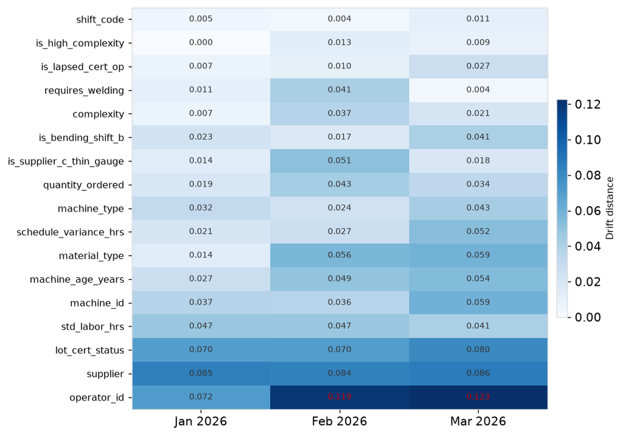

Latest-period detail (Mar 2026), ordered by distance:

| Feature | Type | Test | Drift Distance | Threshold | Status |
| --- | --- | --- | --- | --- | --- |
| operator_id | categorical | Jensen-Shannon distance | 0.1227 | 0.10 | ⚠ Drift |
| supplier | categorical | Jensen-Shannon distance | 0.0863 | 0.10 | ✓ Stable |
| lot_cert_status | categorical | Jensen-Shannon distance | 0.0803 | 0.10 | ✓ Stable |
| machine_id | categorical | Jensen-Shannon distance | 0.0592 | 0.10 | ✓ Stable |
| material_type | categorical | Jensen-Shannon distance | 0.0586 | 0.10 | ✓ Stable |
| machine_age_years | numerical | Wasserstein distance (normed) | 0.0540 | 0.10 | ✓ Stable |
| schedule_variance_hrs | numerical | Jensen-Shannon distance | 0.0525 | 0.10 | ✓ Stable |
| machine_type | categorical | Jensen-Shannon distance | 0.0431 | 0.10 | ✓ Stable |
| std_labor_hrs | numerical | Wasserstein distance (normed) | 0.0409 | 0.10 | ✓ Stable |
| is_bending_shift_b | interaction | Jensen-Shannon distance | 0.0409 | 0.10 | ✓ Stable |
| quantity_ordered | numerical | Wasserstein distance (normed) | 0.0338 | 0.10 | ✓ Stable |
| is_lapsed_cert_op | interaction | Jensen-Shannon distance | 0.0273 | 0.10 | ✓ Stable |
| complexity | categorical | Jensen-Shannon distance | 0.0207 | 0.10 | ✓ Stable |
| is_supplier_c_thin_gauge | interaction | Jensen-Shannon distance | 0.0185 | 0.10 | ✓ Stable |
| shift_code | categorical | Jensen-Shannon distance | 0.0111 | 0.10 | ✓ Stable |
| is_high_complexity | interaction | Jensen-Shannon distance | 0.0088 | 0.10 | ✓ Stable |
| requires_welding | categorical | Jensen-Shannon distance | 0.0036 | 0.10 | ✓ Stable |

Section 2.5

## Data Quality

Null rates, cardinality, and unseen categories for the latest scoring period. Unseen categories are absorbed by the model's `unknown_value=-1` encoding but reduce prediction quality for affected jobs. **The latest period arrives with zero null rates and no unseen categories, which rules out broken inputs and confirms the stable signals above reflect the data faithfully.**

Feature Null Rates, Mar 2026

[figure not shown]

| Feature | Null Rate | Unique Values | New Categories |
| --- | --- | --- | --- |
| machine_type | 0.0% | 4 | - |
| machine_id | 0.0% | 7 | - |
| shift_code | 0.0% | 2 | - |
| operator_id | 0.0% | 20 | - |
| complexity | 0.0% | 3 | - |
| material_type | 0.0% | 7 | - |
| supplier | 0.0% | 4 | - |
| lot_cert_status | 0.0% | 3 | - |
| requires_welding | 0.0% | 2 | - |
| machine_age_years | 0.0% | 7 | - |
| std_labor_hrs | 0.0% | 34 | - |
| quantity_ordered | 0.0% | 21 | - |
| schedule_variance_hrs | 0.0% | 3 | - |
| is_bending_shift_b | 0.0% | 2 | - |
| is_high_complexity | 0.0% | 2 | - |
| is_supplier_c_thin_gauge | 0.0% | 2 | - |
| is_lapsed_cert_op | 0.0% | 2 | - |

Section 3

## Monitoring Log

Model version history and run metadata for traceability.

| Version | Trained | Type | Val ROC-AUC | Stage |
| --- | --- | --- | --- | --- |
| v1 ← current | 2025-12-15 | Xgboost | 0.7450 | Production |